# Raditya Fahritama - Assignment 3

# 1

### Problem Statement

the problem states to perform 2 actions:

```
- create 5x5 array with randn function and use for loop to calculate sum of diagonals of array
- apply three functions to the array
```

###### input:

-

###### output:

5x5 array and sum of diagonals of the array three arrays with three different functions

### Solution Design

1. create list and append number to the list using randn() function
2. create array from list and reshape it to 5x5
3. create sum variables for diagonal and add numbers on the diagonals based on the diagonal algorithm
4. display the results
5. apply three different functions to the array. store to three different arrays and display them

###### assumption:

-

### Code

```python
#!/usr/bin/ python3

"""this code is to create 5x5 array with and create a loop to calculate sum of diagonal of the array """

import numpy as np

"""create list and append number to the list using randn function"""
#assign empty list
randlist = []
n = 5
nn = 25

#loop and append randn numbers to the list
for i in range(nn):
    x = np.random.randn()
    randlist.append(x)

"""creating the array and reshape to 5x5"""
#format the list to .2
randformatted = [round(y,2) for y in randlist ]
#create and reshape the array to 5x5
randarray = np.reshape(randformatted, (n,n))

"""this section is to sum the diagonals of the array"""
#assign sum variables
firstdiag = 0
seconddiag = 0

#loop in range of array
for i in range(0,n):
    for j in range(0,n):
        #if i equals j, add values to sum variable
        if i == j:
            firstdiag = firstdiag + randarray[i][j]
        #if i plus j equal length of array - 1, add values to sum variable
        if i + j == n - 1:
            seconddiag = seconddiag + randarray[i][j]

"""display the results"""
print('The random array : \n',randarray)
print('\nFirst Diagonal sum : %.2f'%firstdiag)
print('\nSecond Diagonal sum : %.2f'%seconddiag)
```

```
The random array :
 [[ 1.25  1.55  1.59  1.73 -0.77]
 [ 1.38  0.05  0.22  0.44  0.46]
 [ 1.75 -1.2   0.73 -1.58 -0.16]
 [-1.47 -0.28  1.73  0.88  2.11]
 [ 1.02 -0.61 -0.46 -2.02 -0.19]]

First Diagonal sum : 2.72

Second Diagonal sum : 1.14
```

```python
#!/usr/bin/ python3

"""this code is to apply functions to the previous array"""

"""this section is the same as above code"""
import numpy as np

randlist = []
n = 5
nn = 25

for i in range(nn):
    x = np.random.randn()
    randlist.append(x)

randformatted = ['%.2f'% y for y in randlist ]
randformatted = [float(i) for i in randformatted]
randarray = np.reshape(randformatted, (n,n))
""""""

"""this section is to apply functions to the array"""
#apply greater() function
greaterzero = np.greater(randarray, 0)
#apply floor() function
floorarr = np.floor(randarray)
#apply exp() function
exparr = np.exp(randarray)

"""display the result"""
print('The original random array : \n',randarray)
print('\nThe Greater than Zero binary status of elements in random array : \n',greaterzero)
print('\nThe Floor of elements in random array : \n',floorarr)
print('\nThe Exponential form of elements in random array : \n',exparr)
```

```
The original random array :
 [[-0.42  0.23  0.7  -0.19 -0.21]
 [-1.35  0.4  -1.21 -0.61 -1.92]
 [ 0.72  0.91 -0.29  0.66 -1.63]
 [ 1.01  0.03  1.51 -0.39  0.87]
 [-0.02  1.5   0.13  0.52 -0.68]]

The Greater than Zero binary status of elements in random array :
 [[False  True  True False False]
 [False  True False False False]
 [ True  True False  True False]
 [ True  True  True False  True]
 [False  True  True  True False]]

The Floor of elements in random array :
 [[-1.  0.  0. -1. -1.]
 [-2.  0. -2. -1. -2.]
 [ 0.  0. -1.  0. -2.]
 [ 1.  0.  1. -1.  0.]
 [-1.  1.  0.  0. -1.]]

The Exponential form of elements in random array :
 [[0.65704682 1.25860001 2.01375271 0.82695913 0.81058425]
 [0.25924026 1.4918247  0.29819728 0.54335087 0.14660696]
 [2.05443321 2.48432253 0.74826357 1.93479233 0.19592957]
 [2.74560102 1.03045453 4.52673079 0.67705687 2.38691085]
 [0.98019867 4.48168907 1.13882838 1.68202765 0.50661699]]
```

### Testing & Exception Handling

###### testing:

- run the program as it is (normal case)

###### exception handling:

- no exception handling performed

### Discussion

the program seems to run the intended solution well based on the output that it provided. i decided to format the values to .2 for easier interpretation of the array. the program solved the problem statement of the question number 1.

# 2

### Problem Statement

the problem states to perform 2 actions:

```
- generate 10x10 array from randint function in range of 0-1000 and use loop to count even number in the array
- generate randomly 8x9 array from normal distribution with mean = 1 and std dev = 0.5. and calculate the mean of the elements where indexes have condition like :  (i+j)%5 == 0  (i is row index and j is column index)
```

###### input:

-

###### output:

1. random integer array and count of even numbers
2. random gaussian distribution array and mean of elements that have the stated condition

### Solution Design

first action

1. create random array with randint function fro 0-1000 with size 10x10
2. assign count variable
3. loop in range and add count everytime elements in array modulo 2 equal to 0
4. display number

second action

1. generate random normal array with mean 1 and sigma 0.5 and size 8x9
2. assign empty list
3. loop in array and append elements to list where element index condition (i+j)%5 == 0
4. append elemets to list and get mean of the list

###### assumption:

-

### Code

```python
#!/usr/bin/ python3

"""this code is to create random 10x10 array with integer on range 1000 and count the even numbers"""
import numpy as np

#assign size number
n = 10
#create random integer array from 0 - 1000
x = np.random.randint(0, 1000, size = (n, n))
print("Random integer array : \n",x,'\n')

#assign count variables
counteven = 0
countodd = 0

"""this section is to loop and see if elements are even or odd"""
for i in range(0,n):
    for j in range(0,n):
        #condition if modulo 2 is equal zero
        if (x[i][j] % 2) == 0:
            counteven += 1
        #condition if modulo 2 is not equal zero
        elif (x[i][j] % 2) != 0:
            countodd += 1

#display the results
print("Count of even number in the array : ",counteven)
print("Count of odd number in the array : ",countodd)
```

```
Random integer array :
 [[  2 159 433 774 294 407 493 101 936  87]
 [110 901 140 189 606 545 237  26 781 758]
 [223 493 798 639 339 239  70  52 276 977]
 [344 696  40 737 536 576 395 619  82 165]
 [814 600 280 563 497 467  33 277 687  16]
 [398 301 570 274 613 270 245 803 119 469]
 [192 569 311 596  44 185 127 340  17 453]
 [724 556 766 791 689 903 369 907 425 961]
 [ 50  76 367 306  23 180 761 741 683 791]
 [968 392 191 727 834 359 728 464 889 605]]

Count of even number in the array :  43
Count of odd number in the array :  57
```

```python
#!/usr/bin/ python3

"""this code is to create random normal array with mean 1 and std dev 0.5"""
import numpy as np

#create the random normal with the conditions
x = np.random.normal(loc = 1, scale = 0.5, size = (8,9))

#round the elements to .3
for i in range(0,8):
    for j in range(0,9):
        x[i][j] = round(x[i][j], 3)

print("Random Gaussian Distribution Array : \n",x)

"""create list and append elements where indexes have the condition"""
#assign list
list = []
#loop to check index and assign value to list
for i in range(0,8):
    for j in range(0,9):
        if ((i+j)%5) == 0:
            elem = x[i][j]
            list.append(elem)

#display results
print("\nElements that indexes have the relation to the condition : \n",list)
#display mean of list
print("\nMean of the elements : ", round(sum(list)/len(list), 3))
```

```
Random Gaussian Distribution Array :
 [[0.218 1.454 1.893 0.764 0.453 0.673 0.447 0.262 0.625]
 [0.622 0.95  0.602 1.26  0.915 0.935 0.874 1.069 1.21 ]
 [0.424 1.573 1.661 0.122 1.401 0.531 0.444 1.492 1.359]
 [0.401 0.974 0.487 1.545 1.035 0.739 0.705 0.822 1.13 ]
 [0.488 1.417 1.096 1.143 1.396 0.625 0.066 2.322 0.773]
 [0.837 0.465 0.103 1.015 0.567 1.109 1.325 0.978 0.976]
 [1.389 1.163 0.785 1.252 0.595 1.868 0.718 1.003 1.387]
 [1.493 1.819 0.638 1.606 0.965 0.529 0.525 0.478 0.95 ]]

Elements that indexes have the relation to the condition :
 [0.218, 0.673, 0.915, 0.122, 1.359, 0.487, 0.822, 1.417, 0.066, 0.837, 1.109, 0.595, 1.606, 0.95]

Mean of the elements :  0.798
```

### Testing & Exception Handling

###### testing:

- run the program as it is (normal case)

###### exception handling:

- no exception handling performed

### Discussion

the program seems to run the intended solution well based on the output that it provided. i also round the float to .3 for the easier interpretation. the program solved the problem statement of the question number 2.

# 3

### Problem Statement

the problem states to perform these actions:

1. Import data mtcars.csv into Python
2. Explore the data and perform a statistical analysis of the data
3. Analyze mpg for cars with different gear, and show your findings
4. Analyze mpg for cars with different carb, and show your findings
5. Find out which attribute has the most impact on mpg

###### input:

-

###### output:

1. dataframe of mtcars
2. EDA of the data
3. analyzation of mpg based on gears and carb
4. feature importance on mpg feature

### Solution Design

1. import csv file to pandas dataframe
2. explore the data by getting statistical values of the data and others
3. analyze continuous data based on gears
4. analyze continuous data based on carb
5. get feature importance on mpg feature

###### assumption:

-

# Importing csv to DataFrame

```python
#!/usr/bin/ python3

"""this code is to load csv to dataframe"""

import pandas as pd
import seaborn as sns
import matplotlib.pyplot as plt

#load the csv file and fisplay
df = pd.read_csv(r'/Users/USER-PC/mtcars.csv')
df
```

|  | model | mpg | cyl | disp | hp | drat | wt | qsec | vs | am | gear | carb |
| --- | --- | --- | --- | --- | --- | --- | --- | --- | --- | --- | --- | --- |
| 0 | Mazda RX4 | 21.0 | 6 | 160.0 | 110 | 3.90 | 2.620 | 16.46 | 0 | 1 | 4 | 4 |
| 1 | Mazda RX4 Wag | 21.0 | 6 | 160.0 | 110 | 3.90 | 2.875 | 17.02 | 0 | 1 | 4 | 4 |
| 2 | Datsun 710 | 22.8 | 4 | 108.0 | 93 | 3.85 | 2.320 | 18.61 | 1 | 1 | 4 | 1 |
| 3 | Hornet 4 Drive | 21.4 | 6 | 258.0 | 110 | 3.08 | 3.215 | 19.44 | 1 | 0 | 3 | 1 |
| 4 | Hornet Sportabout | 18.7 | 8 | 360.0 | 175 | 3.15 | 3.440 | 17.02 | 0 | 0 | 3 | 2 |
| 5 | Valiant | 18.1 | 6 | 225.0 | 105 | 2.76 | 3.460 | 20.22 | 1 | 0 | 3 | 1 |
| 6 | Duster 360 | 14.3 | 8 | 360.0 | 245 | 3.21 | 3.570 | 15.84 | 0 | 0 | 3 | 4 |
| 7 | Merc 240D | 24.4 | 4 | 146.7 | 62 | 3.69 | 3.190 | 20.00 | 1 | 0 | 4 | 2 |
| 8 | Merc 230 | 22.8 | 4 | 140.8 | 95 | 3.92 | 3.150 | 22.90 | 1 | 0 | 4 | 2 |
| 9 | Merc 280 | 19.2 | 6 | 167.6 | 123 | 3.92 | 3.440 | 18.30 | 1 | 0 | 4 | 4 |
| 10 | Merc 280C | 17.8 | 6 | 167.6 | 123 | 3.92 | 3.440 | 18.90 | 1 | 0 | 4 | 4 |
| 11 | Merc 450SE | 16.4 | 8 | 275.8 | 180 | 3.07 | 4.070 | 17.40 | 0 | 0 | 3 | 3 |
| 12 | Merc 450SL | 17.3 | 8 | 275.8 | 180 | 3.07 | 3.730 | 17.60 | 0 | 0 | 3 | 3 |
| 13 | Merc 450SLC | 15.2 | 8 | 275.8 | 180 | 3.07 | 3.780 | 18.00 | 0 | 0 | 3 | 3 |
| 14 | Cadillac Fleetwood | 10.4 | 8 | 472.0 | 205 | 2.93 | 5.250 | 17.98 | 0 | 0 | 3 | 4 |
| 15 | Lincoln Continental | 10.4 | 8 | 460.0 | 215 | 3.00 | 5.424 | 17.82 | 0 | 0 | 3 | 4 |
| 16 | Chrysler Imperial | 14.7 | 8 | 440.0 | 230 | 3.23 | 5.345 | 17.42 | 0 | 0 | 3 | 4 |
| 17 | Fiat 128 | 32.4 | 4 | 78.7 | 66 | 4.08 | 2.200 | 19.47 | 1 | 1 | 4 | 1 |
| 18 | Honda Civic | 30.4 | 4 | 75.7 | 52 | 4.93 | 1.615 | 18.52 | 1 | 1 | 4 | 2 |
| 19 | Toyota Corolla | 33.9 | 4 | 71.1 | 65 | 4.22 | 1.835 | 19.90 | 1 | 1 | 4 | 1 |
| 20 | Toyota Corona | 21.5 | 4 | 120.1 | 97 | 3.70 | 2.465 | 20.01 | 1 | 0 | 3 | 1 |
| 21 | Dodge Challenger | 15.5 | 8 | 318.0 | 150 | 2.76 | 3.520 | 16.87 | 0 | 0 | 3 | 2 |
| 22 | AMC Javelin | 15.2 | 8 | 304.0 | 150 | 3.15 | 3.435 | 17.30 | 0 | 0 | 3 | 2 |
| 23 | Camaro Z28 | 13.3 | 8 | 350.0 | 245 | 3.73 | 3.840 | 15.41 | 0 | 0 | 3 | 4 |
| 24 | Pontiac Firebird | 19.2 | 8 | 400.0 | 175 | 3.08 | 3.845 | 17.05 | 0 | 0 | 3 | 2 |
| 25 | Fiat X1-9 | 27.3 | 4 | 79.0 | 66 | 4.08 | 1.935 | 18.90 | 1 | 1 | 4 | 1 |
| 26 | Porsche 914-2 | 26.0 | 4 | 120.3 | 91 | 4.43 | 2.140 | 16.70 | 0 | 1 | 5 | 2 |
| 27 | Lotus Europa | 30.4 | 4 | 95.1 | 113 | 3.77 | 1.513 | 16.90 | 1 | 1 | 5 | 2 |
| 28 | Ford Pantera L | 15.8 | 8 | 351.0 | 264 | 4.22 | 3.170 | 14.50 | 0 | 1 | 5 | 4 |
| 29 | Ferrari Dino | 19.7 | 6 | 145.0 | 175 | 3.62 | 2.770 | 15.50 | 0 | 1 | 5 | 6 |
| 30 | Maserati Bora | 15.0 | 8 | 301.0 | 335 | 3.54 | 3.570 | 14.60 | 0 | 1 | 5 | 8 |
| 31 | Volvo 142E | 21.4 | 4 | 121.0 | 109 | 4.11 | 2.780 | 18.60 | 1 | 1 | 4 | 2 |

# Exploring the Data

```python
"""these cells are to explore the data"""

#check if there's null
df.isnull().values.any()
```

```
False
```

```python
#getting description on numerical features
df.describe()
```

|  | mpg | cyl | disp | hp | drat | wt | qsec | vs | am | gear | carb |
| --- | --- | --- | --- | --- | --- | --- | --- | --- | --- | --- | --- |
| count | 32.000000 | 32.000000 | 32.000000 | 32.000000 | 32.000000 | 32.000000 | 32.000000 | 32.000000 | 32.000000 | 32.000000 | 32.0000 |
| mean | 20.090625 | 6.187500 | 230.721875 | 146.687500 | 3.596563 | 3.217250 | 17.848750 | 0.437500 | 0.406250 | 3.687500 | 2.8125 |
| std | 6.026948 | 1.785922 | 123.938694 | 68.562868 | 0.534679 | 0.978457 | 1.786943 | 0.504016 | 0.498991 | 0.737804 | 1.6152 |
| min | 10.400000 | 4.000000 | 71.100000 | 52.000000 | 2.760000 | 1.513000 | 14.500000 | 0.000000 | 0.000000 | 3.000000 | 1.0000 |
| 25% | 15.425000 | 4.000000 | 120.825000 | 96.500000 | 3.080000 | 2.581250 | 16.892500 | 0.000000 | 0.000000 | 3.000000 | 2.0000 |
| 50% | 19.200000 | 6.000000 | 196.300000 | 123.000000 | 3.695000 | 3.325000 | 17.710000 | 0.000000 | 0.000000 | 4.000000 | 2.0000 |
| 75% | 22.800000 | 8.000000 | 326.000000 | 180.000000 | 3.920000 | 3.610000 | 18.900000 | 1.000000 | 1.000000 | 4.000000 | 4.0000 |
| max | 33.900000 | 8.000000 | 472.000000 | 335.000000 | 4.930000 | 5.424000 | 22.900000 | 1.000000 | 1.000000 | 5.000000 | 8.0000 |

with this, we can see the statistical analysis of the numerical data. including mean, standard deviation, min-max values, and quartiles for each column.

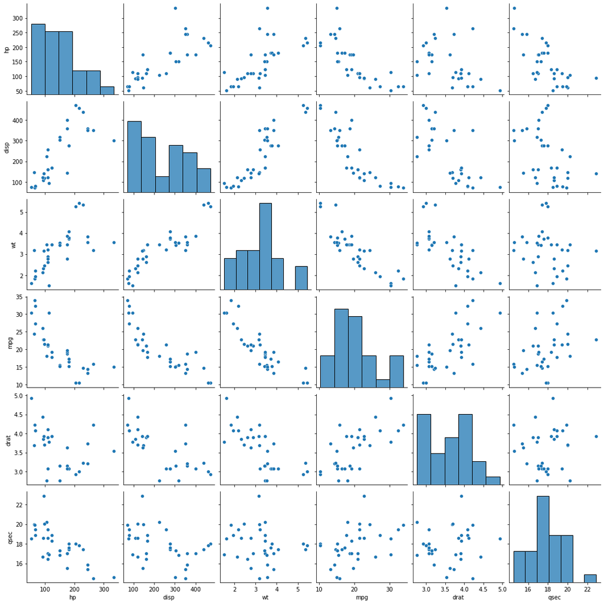

```python
#showing pairplot on continuous numeric
dfpairplt3 = df.loc[:,["hp","disp","wt","mpg","drat","qsec"]]
sns.pairplot(dfpairplt3)
```

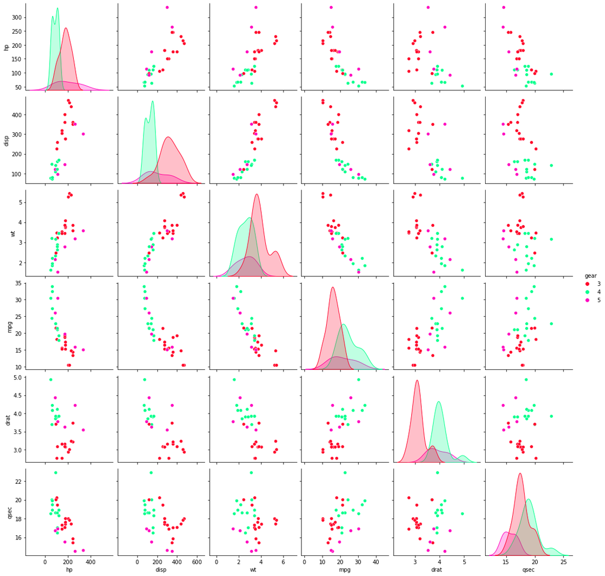

```python
#showing pairplot on continuous based on number of gears
dfpairplt = df.loc[:,["hp","disp","wt","mpg","drat","qsec", "gear"]]
sns.pairplot(dfpairplt, hue = "gear", palette = "gist_rainbow")
```

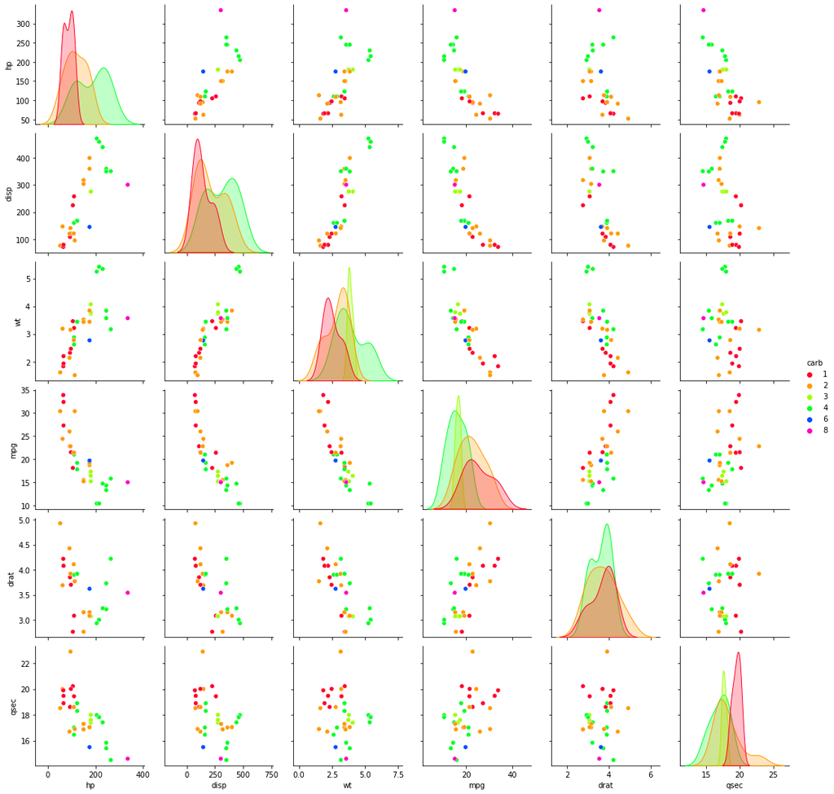

```python
#showing pairplot based on number of carburators
dfpairplt2 = df.loc[:,["hp","disp","wt","mpg","drat","qsec","carb"]]
sns.pairplot(dfpairplt2, hue = "carb", palette = "gist_rainbow")
```

```python
#showing correlation in data frame
dfcorr = df.corr()
dfcorr.style.background_gradient(cmap='YlOrRd')
```

|  | mpg | cyl | disp | hp | drat | wt | qsec | vs | am | gear | carb |
| --- | --- | --- | --- | --- | --- | --- | --- | --- | --- | --- | --- |
| mpg | 1.000000 | -0.852162 | -0.847551 | -0.776168 | 0.681172 | -0.867659 | 0.418684 | 0.664039 | 0.599832 | 0.480285 | -0.550925 |
| cyl | -0.852162 | 1.000000 | 0.902033 | 0.832447 | -0.699938 | 0.782496 | -0.591242 | -0.810812 | -0.522607 | -0.492687 | 0.526988 |
| disp | -0.847551 | 0.902033 | 1.000000 | 0.790949 | -0.710214 | 0.887980 | -0.433698 | -0.710416 | -0.591227 | -0.555569 | 0.394977 |
| hp | -0.776168 | 0.832447 | 0.790949 | 1.000000 | -0.448759 | 0.658748 | -0.708223 | -0.723097 | -0.243204 | -0.125704 | 0.749812 |
| drat | 0.681172 | -0.699938 | -0.710214 | -0.448759 | 1.000000 | -0.712441 | 0.091205 | 0.440278 | 0.712711 | 0.699610 | -0.090790 |
| wt | -0.867659 | 0.782496 | 0.887980 | 0.658748 | -0.712441 | 1.000000 | -0.174716 | -0.554916 | -0.692495 | -0.583287 | 0.427606 |
| qsec | 0.418684 | -0.591242 | -0.433698 | -0.708223 | 0.091205 | -0.174716 | 1.000000 | 0.744535 | -0.229861 | -0.212682 | -0.656249 |
| vs | 0.664039 | -0.810812 | -0.710416 | -0.723097 | 0.440278 | -0.554916 | 0.744535 | 1.000000 | 0.168345 | 0.206023 | -0.569607 |
| am | 0.599832 | -0.522607 | -0.591227 | -0.243204 | 0.712711 | -0.692495 | -0.229861 | 0.168345 | 1.000000 | 0.794059 | 0.057534 |
| gear | 0.480285 | -0.492687 | -0.555569 | -0.125704 | 0.699610 | -0.583287 | -0.212682 | 0.206023 | 0.794059 | 1.000000 | 0.274073 |
| carb | -0.550925 | 0.526988 | 0.394977 | 0.749812 | -0.090790 | 0.427606 | -0.656249 | -0.569607 | 0.057534 | 0.274073 | 1.000000 |

# Analyzing mpg based on number of forward gears

```python
"""these cells are to analyze mpg based on gears"""

#create df based on gears on continuous
df1 = df[['gear','mpg','hp','wt','qsec']]
df1 = df1.groupby(['gear'], as_index=True).mean()
df1 = round(df1,2)
df1
```

| gear | mpg | hp | wt | qsec |
| --- | --- | --- | --- | --- |
| 3 | 16.11 | 176.13 | 3.89 | 17.69 |
| 4 | 24.53 | 89.50 | 2.62 | 18.96 |
| 5 | 21.38 | 195.60 | 2.63 | 15.64 |

we can see that average mpg for 4 gears is higher than any other number of gears.

```python
#getting number based on gears
x = df["gear"].value_counts()
x
```

```
3    15
4    12
5     5
Name: gear, dtype: int64
```

count of data with 3 gears is the highest. followed by 4 gears and 5 gears.

[output not shown]

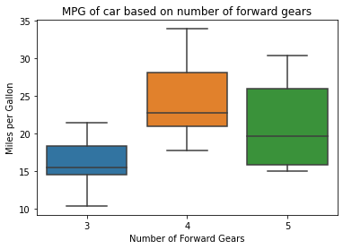

```python
#showing boxplot on mpg based on gears
sns.boxplot(
    x=df["gear"],
    y=df["mpg"]
).set(
    xlabel = "Number of Forward Gears",
    ylabel = "Miles per Gallon",
    title = "MPG of car based on number of forward gears"
)
```

we can see from the boxplot, 3 gears cars mpg variation is not as varied as 4 gears and 5 gears.

# Analyzing mpg based on number of carburators

```python
"""these cells are to analyze mpg based on carb"""

#create df based on carb on continuous
df2 = df[['carb','mpg','hp','wt','qsec']]
df2 = df2.groupby(['carb'], as_index=True).mean()
df2 = round(df2,2)
df2
```

| carb | mpg | hp | wt | qsec |
| --- | --- | --- | --- | --- |
| 1 | 25.34 | 86.0 | 2.49 | 19.51 |
| 2 | 22.40 | 117.2 | 2.86 | 18.19 |
| 3 | 16.30 | 180.0 | 3.86 | 17.67 |
| 4 | 15.79 | 187.0 | 3.90 | 16.96 |
| 6 | 19.70 | 175.0 | 2.77 | 15.50 |
| 8 | 15.00 | 335.0 | 3.57 | 14.60 |

we can see average mpg for cars with 1 carburator is the highest than cars with more carburators.

```python
#getting number based on carb
x = df["carb"].value_counts()
x
```

```
4    10
2    10
1     7
3     3
6     1
8     1
Name: carb, dtype: int64
```

we can see that the data contains cars with 4 and 2 carburators the highest than any other number.

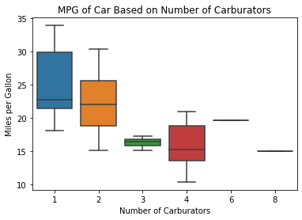

```python
#showing boxplot on mpg based on gears
ax = sns.boxplot(
    x=df["carb"],
    y=df["mpg"]
).set(
    xlabel = "Number of Carburators",
    ylabel = "Miles per Gallon",
    title = "MPG of Car Based on Number of Carburators"
)
```

we can see from the boxplot, carburator number 1, 2, and 4 have the most variations. this can be caused by the data count for each carburator numbers.

# Finding most impactful feature on MPG

```python
"""this code is to get the most impactful feature on MPG"""

#importing modules
from sklearn.ensemble import RandomForestRegressor
from sklearn.preprocessing import StandardScaler
from sklearn.model_selection import train_test_split

#getting df to train
X = df.drop(['model', 'mpg'], axis=1)
y = df['mpg']
X_train, X_test, y_train, y_test = train_test_split(X, y, test_size=0.20, random_state=42)

#scaling the data
ss = StandardScaler()
X_train_scaled = ss.fit_transform(X_train)
X_test_scaled = ss.transform(X_test)

#appying random forest regressor and train
model = RandomForestRegressor()
model.fit(X_train_scaled, y_train)
```

```
RandomForestRegressor()
```

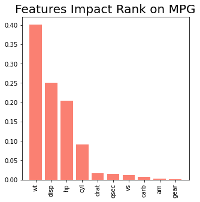

```python
"""this function is to plot the feature importance rank"""

#defining the function
def featureimp(columns, importances):
    importances = pd.DataFrame(data={
        'Attribute': columns,
        'Importance': importances
    })
    importances = importances.sort_values(by='Importance', ascending=False)
    plt.figure(figsize=(5, 5))
    plt.bar(x=importances['Attribute'], height=importances['Importance'], color='salmon')
    plt.title('Features Impact Rank on MPG' , size=20)
    plt.xticks(rotation='vertical')
    plt.show()

#getting model feature importance
featimp = model.feature_importances_
xcolumn = X_train.columns
#applying the function
featureimp(xcolumn, featimp)
```

we can see from feature importance of random forest regressor, the wt, disp, and hp are the most impactful features for mpg.

### Testing & Exception Handling

###### testing:

- run the program as it is (normal case)

###### exception handling:

- no exception handling performed

### Discussion

the program seems to run the intended solution well based on the output that it provided. the program solved the problem statement of the question number 3.